# Homework 2

Mutua Fadhla Mohamed

# Impostazioni progetto

```r
library(ggplot2)

plot_theme = theme_minimal() +
    theme(
        plot.title = element_text(face = "bold", hjust = 0.5),
        plot.subtitle = element_text(hjust = 0.5),
        axis.line = element_line(color = "darkgrey", size = 0.4),
        axis.ticks = element_line(color = "black"))
theme_set(plot_theme)
```

# Lettura dati

```r
credit_card = read.csv2("./credit_card.csv", sep = ",", stringsAsFactors=T, row.names=1)
```

# Trasformazione in numerica

```r
str(credit_card)
```

```
## 'data.frame':    10127 obs. of  22 variables:
##  $ Attrition_Flag                                                                                                                    : Factor w/ 2 levels "Attrited Customer",..: 2 2 2 2 2 2 2 2 2 2 ...
##  $ Customer_Age                                                                                                                      : int  45 49 51 40 40 44 51 32 37 48 ...
##  $ Gender                                                                                                                            : Factor w/ 2 levels "F","M": 2 1 2 1 2 2 2 2 2 2 ...
##  $ Dependent_count                                                                                                                   : int  3 5 3 4 3 2 4 0 3 2 ...
##  $ Education_Level                                                                                                                   : Factor w/ 7 levels "College","Doctorate",..: 4 3 3 4 6 3 7 4 6 3 ...
##  $ Marital_Status                                                                                                                    : Factor w/ 4 levels "Divorced","Married",..: 2 3 2 4 2 2 2 4 3 3 ...
##  $ Income_Category                                                                                                                   : Factor w/ 6 levels "$120K +","$40K - $60K",..: 3 5 4 5 3 2 1 3 3 4 ...
##  $ Card_Category                                                                                                                     : Factor w/ 4 levels "Blue","Gold",..: 1 1 1 1 1 1 2 4 1 1 ...
##  $ Months_on_book                                                                                                                    : int  39 44 36 34 21 36 46 27 36 36 ...
##  $ Total_Relationship_Count                                                                                                          : int  5 6 4 3 5 3 6 2 5 6 ...
##  $ Months_Inactive_12_mon                                                                                                            : int  1 1 1 4 1 1 1 2 2 3 ...
##  $ Contacts_Count_12_mon                                                                                                             : int  3 2 0 1 0 2 3 2 0 3 ...
##  $ Credit_Limit                                                                                                                      : Factor w/ 6205 levels "10001","10007",..: 519 5724 3719 3613 4464 4081 3748 3136 2207 333 ...
##  $ Total_Revolving_Bal                                                                                                               : int  777 864 0 2517 0 1247 2264 1396 2517 1677 ...
##  $ Avg_Open_To_Buy                                                                                                                   : Factor w/ 6813 levels "10","100","1000",..: 525 5881 3964 6124 4699 3018 3501 3023 2055 6808 ...
##  $ Total_Amt_Chng_Q4_Q1                                                                                                              : Factor w/ 1158 levels "0","0.01","0.018",..: 988 1074 1155 1021 1146 1010 1137 1148 1157 1070 ...
##  $ Total_Trans_Amt                                                                                                                   : int  1144 1291 1887 1171 816 1088 1330 1538 1350 1441 ...
##  $ Total_Trans_Ct                                                                                                                    : int  42 33 20 20 28 24 31 36 24 32 ...
##  $ Total_Ct_Chng_Q4_Q1                                                                                                               : Factor w/ 830 levels "0","0.028","0.029",..: 792 830 819 819 822 508 400 393 711 539 ...
##  $ Avg_Utilization_Ratio                                                                                                             : Factor w/ 964 levels "0","0.004","0.005",..: 59 103 1 758 1 309 64 46 111 142 ...
##  $ Naive_Bayes_Classifier_Attrition_Flag_Card_Category_Contacts_Count_12_mon_Dependent_count_Education_Level_Months_Inactive_12_mon_1: Factor w/ 1704 levels "0.00010018","0.00010043",..: 1667 1466 1303 149 1305 1453 113 1636 1403 547 ...
##  $ Naive_Bayes_Classifier_Attrition_Flag_Card_Category_Contacts_Count_12_mon_Dependent_count_Education_Level_Months_Inactive_12_mon_2: Factor w/ 640 levels "0.00041998","0.00042446",..: 632 635 639 628 639 635 629 632 637 611 ...
```

Come si vede, alcuni dei variabili quantitativi sono fattori

```r
is_numeric_factor <- function(factor_column) {
  all(!is.na(suppressWarnings(as.numeric(as.character(factor_column)))))
}

# Fuzione che converte fact a num
convert_factors_to_numeric <- function(data) {
  for (col in names(data)) {
    if (is.factor(data[[col]])) {
      if (is_numeric_factor(data[[col]])) {
        data[[col]] = as.numeric(as.character(data[[col]]))
      }
    }
  }
  return(data)
}

credit_w_numeric = convert_factors_to_numeric(credit_card)
str(credit_w_numeric)
```

```
## 'data.frame':    10127 obs. of  22 variables:
##  $ Attrition_Flag                                                                                                                    : Factor w/ 2 levels "Attrited Customer",..: 2 2 2 2 2 2 2 2 2 2 ...
##  $ Customer_Age                                                                                                                      : int  45 49 51 40 40 44 51 32 37 48 ...
##  $ Gender                                                                                                                            : Factor w/ 2 levels "F","M": 2 1 2 1 2 2 2 2 2 2 ...
##  $ Dependent_count                                                                                                                   : int  3 5 3 4 3 2 4 0 3 2 ...
##  $ Education_Level                                                                                                                   : Factor w/ 7 levels "College","Doctorate",..: 4 3 3 4 6 3 7 4 6 3 ...
##  $ Marital_Status                                                                                                                    : Factor w/ 4 levels "Divorced","Married",..: 2 3 2 4 2 2 2 4 3 3 ...
##  $ Income_Category                                                                                                                   : Factor w/ 6 levels "$120K +","$40K - $60K",..: 3 5 4 5 3 2 1 3 3 4 ...
##  $ Card_Category                                                                                                                     : Factor w/ 4 levels "Blue","Gold",..: 1 1 1 1 1 1 2 4 1 1 ...
##  $ Months_on_book                                                                                                                    : int  39 44 36 34 21 36 46 27 36 36 ...
##  $ Total_Relationship_Count                                                                                                          : int  5 6 4 3 5 3 6 2 5 6 ...
##  $ Months_Inactive_12_mon                                                                                                            : int  1 1 1 4 1 1 1 2 2 3 ...
##  $ Contacts_Count_12_mon                                                                                                             : int  3 2 0 1 0 2 3 2 0 3 ...
##  $ Credit_Limit                                                                                                                      : num  12691 8256 3418 3313 4716 ...
##  $ Total_Revolving_Bal                                                                                                               : int  777 864 0 2517 0 1247 2264 1396 2517 1677 ...
##  $ Avg_Open_To_Buy                                                                                                                   : num  11914 7392 3418 796 4716 ...
##  $ Total_Amt_Chng_Q4_Q1                                                                                                              : num  1.33 1.54 2.59 1.4 2.17 ...
##  $ Total_Trans_Amt                                                                                                                   : int  1144 1291 1887 1171 816 1088 1330 1538 1350 1441 ...
##  $ Total_Trans_Ct                                                                                                                    : int  42 33 20 20 28 24 31 36 24 32 ...
##  $ Total_Ct_Chng_Q4_Q1                                                                                                               : num  1.62 3.71 2.33 2.33 2.5 ...
##  $ Avg_Utilization_Ratio                                                                                                             : num  0.061 0.105 0 0.76 0 0.311 0.066 0.048 0.113 0.144 ...
##  $ Naive_Bayes_Classifier_Attrition_Flag_Card_Category_Contacts_Count_12_mon_Dependent_count_Education_Level_Months_Inactive_12_mon_1: num  9.34e-05 5.69e-05 2.11e-05 1.34e-04 2.17e-05 ...
##  $ Naive_Bayes_Classifier_Attrition_Flag_Card_Category_Contacts_Count_12_mon_Dependent_count_Education_Level_Months_Inactive_12_mon_2: num  1 1 1 1 1 ...
```

```r
attach(credit_w_numeric)
```

Adesso tutti i variabili quantitaivi sono numerici

# Scelta di colonne

```r
credit_card_numeric_bool = sapply(credit_w_numeric,is.numeric)
credit_card_numeric_names = names(credit_card[credit_card_numeric_bool])
# Rimozione dell'ultimo e penultimo in quanto usato per machine learning
# e del primo in quanto ID delle persone
credit_card_numeric_names = credit_card_numeric_names[c(-15,-16)]
print("Colonne scelte: ")
```

```
## [1] "Colonne scelte: "
```

```r
print(credit_card_numeric_names)
```

```
##  [1] "Customer_Age"             "Dependent_count"
##  [3] "Months_on_book"           "Total_Relationship_Count"
##  [5] "Months_Inactive_12_mon"   "Contacts_Count_12_mon"
##  [7] "Credit_Limit"             "Total_Revolving_Bal"
##  [9] "Avg_Open_To_Buy"          "Total_Amt_Chng_Q4_Q1"
## [11] "Total_Trans_Amt"          "Total_Trans_Ct"
## [13] "Total_Ct_Chng_Q4_Q1"      "Avg_Utilization_Ratio"
```

# Analisi Primaria

```r
Analisi_Primaria <- function(data){
  print(paste("Numeri di osservazione: ",nrow(data)))
  print(paste("Numeri di variabili: ",ncol(data)))
}
Analisi_Primaria(credit_w_numeric[,credit_card_numeric_names])
```

```
## [1] "Numeri di osservazione:  10127"
## [1] "Numeri di variabili:  14"
```

```r
str(credit_w_numeric[,credit_card_numeric_names])
```

```
## 'data.frame':    10127 obs. of  14 variables:
##  $ Customer_Age            : int  45 49 51 40 40 44 51 32 37 48 ...
##  $ Dependent_count         : int  3 5 3 4 3 2 4 0 3 2 ...
##  $ Months_on_book          : int  39 44 36 34 21 36 46 27 36 36 ...
##  $ Total_Relationship_Count: int  5 6 4 3 5 3 6 2 5 6 ...
##  $ Months_Inactive_12_mon  : int  1 1 1 4 1 1 1 2 2 3 ...
##  $ Contacts_Count_12_mon   : int  3 2 0 1 0 2 3 2 0 3 ...
##  $ Credit_Limit            : num  12691 8256 3418 3313 4716 ...
##  $ Total_Revolving_Bal     : int  777 864 0 2517 0 1247 2264 1396 2517 1677 ...
##  $ Avg_Open_To_Buy         : num  11914 7392 3418 796 4716 ...
##  $ Total_Amt_Chng_Q4_Q1    : num  1.33 1.54 2.59 1.4 2.17 ...
##  $ Total_Trans_Amt         : int  1144 1291 1887 1171 816 1088 1330 1538 1350 1441 ...
##  $ Total_Trans_Ct          : int  42 33 20 20 28 24 31 36 24 32 ...
##  $ Total_Ct_Chng_Q4_Q1     : num  1.62 3.71 2.33 2.33 2.5 ...
##  $ Avg_Utilization_Ratio   : num  0.061 0.105 0 0.76 0 0.311 0.066 0.048 0.113 0.144 ...
```

# Analisi Univariata

```r
univariate_analysis <- function(data, colname) {
  result = list()

  result[[colname]] = list(
    # Summary statistics including min, 1st and 3rd quartile, mean, median, max
    Summary = summary(data),
    # Variance
    Variance = round(var(data), 2),
    # Standard Deviation
    Standard_Deviation = round(sd(data), 2),
    # Mode calculation
    Moda = Mode(data)
  )
  return(result)
}

Mode <- function(data) {
  # I valori unique
  uniq_vals = unique(data)
  # Conto qunti sono
  tab = tabulate(match(data, uniq_vals))
  # Trovo il piu grande
  modes = uniq_vals[tab == max(tab)]
  # Ritorno come lista
  list(Mode = modes, Frequency = max(tab))
}

sum_info_c = lapply(credit_card_numeric_names, function(ele) {
  colummn = na.omit(credit_w_numeric[, ele])
  univariate_analysis(colummn, ele)
})
```

# Funzione di Visualizazione continuo

```r
visualization_continuos <- function(data,sumary,colname){
  # Metto in modo da vedere 4 grafici
  par(mfrow = c(2,2))
  print(sumary)
  boxplot(data, horizontal = T, main = paste("Boxplot of ", colname))
  hist(data, probability = T, col = 2, main = paste("Hist of ", colname))
  #Metto in comparazione la sua distribuzione
  curve(dnorm(x, mean = mean(data), sd = sd(data)),
        add=T, col = 4)
  print(density(data))
  plot(density(data), main = paste("Desnity Distribution of ", colname))

  # Confronto qq-norm della distribuzione con la retta qq-norm della norma
  # per vedere se la distribuzione si avvicina alla norma e per quali intervalli
  qqnorm(data, col = 3, main = paste("QQnorm of ", colname))
  qqline(data, col = 5, pch = 10)
}
```

# Funzione di Visualizazione discreta

```r
visualization_discrete <- function(data,sumary,colname){
  par(mfrow = c(1,1))
  print(sumary)
  # Quante volte occore per ogni unique
  print("freq: ")
  cat("\n")
  print(table(data))
  cat("\n")
  print("percintile: ")
  # E il suo percentile
  cat("\n")
  print(prop.table(table(data))*100)
  cat("\n")
  barplot(table(data), col = 2, main = paste("Barplot of ", colname))
}
```

# Rimozione 0

```r
# funzione per rimuovere lo 0 in quanto tanti dei variabili contengono lo 0
# che domina il resto dei dati
rm_0 <- function(data){
  imp_data = data
  imp_data[imp_data == 0] = NA
  imp_data = na.omit(imp_data)
  return(imp_data)
}
```

# Rimozione degli outlier attraverso intervallo di confidenza

```r
# funzione per rimuove le outlier per mostrare piu meglio l'andamento della
# distribuzione
rm_oultiers <- function(data, CI){
  mean_data = mean(data)
  sd_data = sd(data)
  confidence_level = CI
  z_score = qnorm((1 + confidence_level) / 2)

  lower_bound = mean_data - z_score * sd_data
  upper_bound = mean_data + z_score * sd_data

  data_in_ci = data[data >= lower_bound & data <= upper_bound]
  return(data_in_ci)
}
```

# 1: Visualizazione Customer_Age

```r
visualization_continuos(na.omit(credit_w_numeric[,"Customer_Age"]), sum_info_c[1],"Customer_Age")
```

```
## [[1]]
## [[1]]$Customer_Age
## [[1]]$Customer_Age$Summary
##    Min. 1st Qu.  Median    Mean 3rd Qu.    Max.
##   26.00   41.00   46.00   46.33   52.00   73.00
##
## [[1]]$Customer_Age$Variance
## [1] 64.27
##
## [[1]]$Customer_Age$Standard_Deviation
## [1] 8.02
##
## [[1]]$Customer_Age$Moda
## [[1]]$Customer_Age$Moda$Mode
## [1] 44
##
## [[1]]$Customer_Age$Moda$Frequency
## [1] 500
```

```
##
## Call:
##  density.default(x = data)
##
## Data: data (10127 obs.); Bandwidth 'bw' = 1.141
##
##        x               y
##  Min.   :22.58   Min.   :3.900e-07
##  1st Qu.:36.04   1st Qu.:3.047e-03
##  Median :49.50   Median :1.262e-02
##  Mean   :49.50   Mean   :1.855e-02
##  3rd Qu.:62.96   3rd Qu.:3.461e-02
##  Max.   :76.42   Max.   :4.824e-02
```

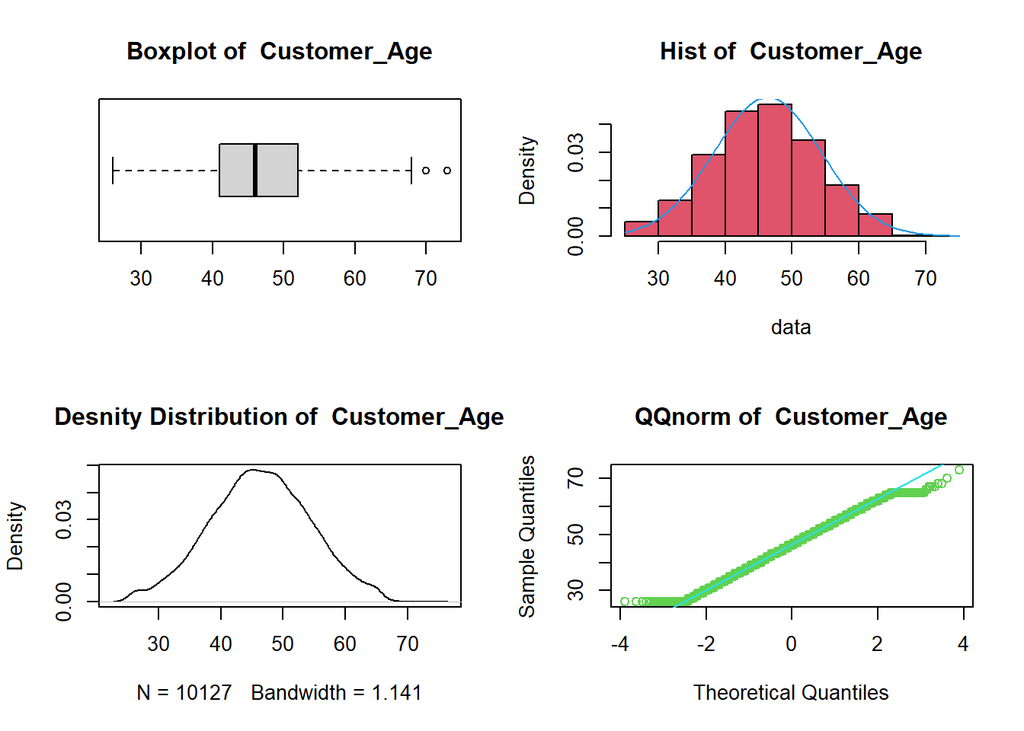

Possiamo dedurre che la distribuzione è per lo più una gaussiana e che la maggior parte delle persone compreso tra 41.00 e 52.00 anni, essendo rispettivamente il 1° e il 3° quantile e con maggior densita alineati alla retta qq della norma La piu grande occoranze è 500 a 44 anni alineati alla retta qq della norma. Gli outlier invece si trovano ad eta di 73 e 70

# 2: Visualizazione Dependent_count

```r
visualization_discrete(na.omit(credit_w_numeric[,"Dependent_count"]), sum_info_c[2],"Dependent_count")
```

```
## [[1]]
## [[1]]$Dependent_count
## [[1]]$Dependent_count$Summary
##    Min. 1st Qu.  Median    Mean 3rd Qu.    Max.
##   0.000   1.000   2.000   2.346   3.000   5.000
##
## [[1]]$Dependent_count$Variance
## [1] 1.69
##
## [[1]]$Dependent_count$Standard_Deviation
## [1] 1.3
##
## [[1]]$Dependent_count$Moda
## [[1]]$Dependent_count$Moda$Mode
## [1] 3
##
## [[1]]$Dependent_count$Moda$Frequency
## [1] 2732
##
##
##
##
## [1] "freq: "
##
## data
##    0    1    2    3    4    5
##  904 1838 2655 2732 1574  424
##
## [1] "percintile: "
##
## data
##         0         1         2         3         4         5
##  8.926632 18.149501 26.217044 26.977387 15.542609  4.186827
```

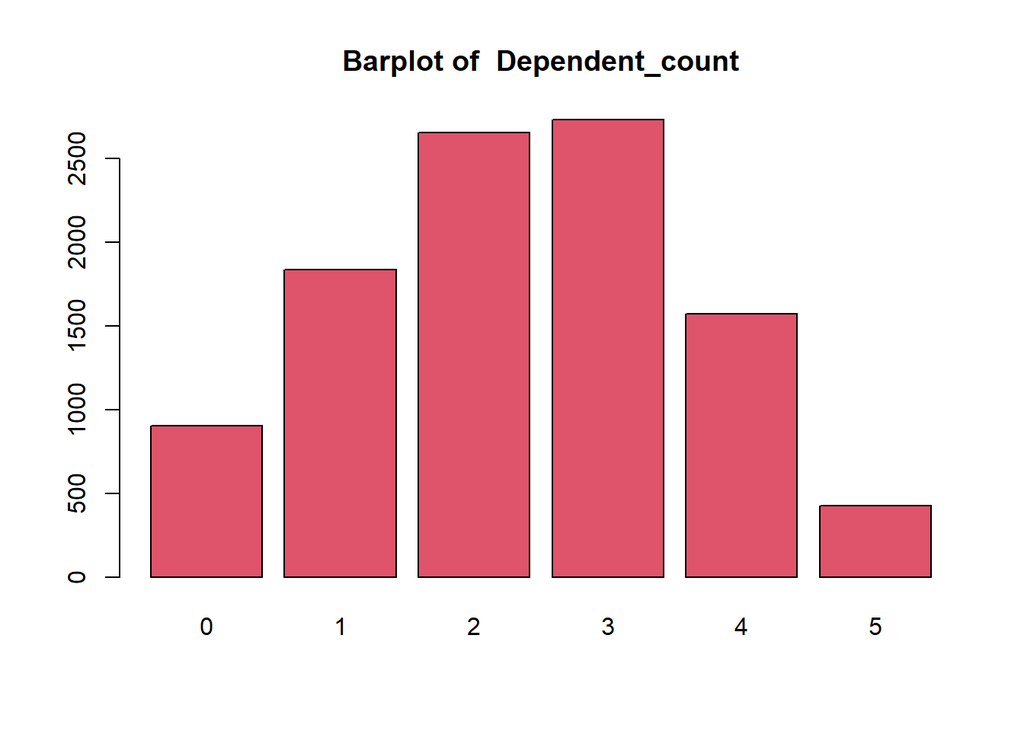

si osservare che la maggior parte delle persone hanno tra 1 e 3 dipendenti coprendo il ~=71.35%, con la mggior parte avendo 3 dipendenti a 2732 occoranze (~=26.98%)

# 3: Visualizazione Months_on_book

```r
visualization_continuos(na.omit(credit_w_numeric[,"Months_on_book"]), sum_info_c[3],"Months_on_book")
```

```
## [[1]]
## [[1]]$Months_on_book
## [[1]]$Months_on_book$Summary
##    Min. 1st Qu.  Median    Mean 3rd Qu.    Max.
##   13.00   31.00   36.00   35.93   40.00   56.00
##
## [[1]]$Months_on_book$Variance
## [1] 63.78
##
## [[1]]$Months_on_book$Standard_Deviation
## [1] 7.99
##
## [[1]]$Months_on_book$Moda
## [[1]]$Months_on_book$Moda$Mode
## [1] 36
##
## [[1]]$Months_on_book$Moda$Frequency
## [1] 2463
```

```
##
## Call:
##  density.default(x = data)
##
## Data: data (10127 obs.); Bandwidth 'bw' = 0.9556
##
##        x               y
##  Min.   :10.13   Min.   :3.333e-05
##  1st Qu.:22.32   1st Qu.:5.783e-03
##  Median :34.50   Median :1.472e-02
##  Mean   :34.50   Mean   :2.050e-02
##  3rd Qu.:46.68   3rd Qu.:2.774e-02
##  Max.   :58.87   Max.   :1.209e-01
```

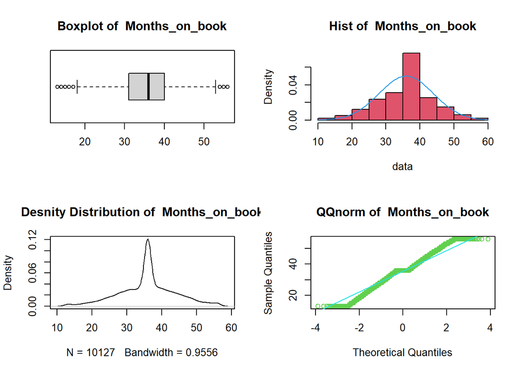

Possiamo dedurre che la distribuzione è per lo più una gaussiana e che la maggior parte delle persone sono registrati con la banca fra 31.00 e 40.00 mesi, La piu grande occoranze è 2463 a 36 mesi

# 4: Visualizazione Total_Relationship_Count

```r
visualization_discrete(na.omit(
  credit_w_numeric[,"Total_Relationship_Count"]), sum_info_c[4],"Total_Relationship_Count")
```

```
## [[1]]
## [[1]]$Total_Relationship_Count
## [[1]]$Total_Relationship_Count$Summary
##    Min. 1st Qu.  Median    Mean 3rd Qu.    Max.
##   1.000   3.000   4.000   3.813   5.000   6.000
##
## [[1]]$Total_Relationship_Count$Variance
## [1] 2.42
##
## [[1]]$Total_Relationship_Count$Standard_Deviation
## [1] 1.55
##
## [[1]]$Total_Relationship_Count$Moda
## [[1]]$Total_Relationship_Count$Moda$Mode
## [1] 3
##
## [[1]]$Total_Relationship_Count$Moda$Frequency
## [1] 2305
##
##
##
##
## [1] "freq: "
##
## data
##    1    2    3    4    5    6
##  910 1243 2305 1912 1891 1866
##
## [1] "percintile: "
##
## data
##         1         2         3         4         5         6
##  8.985879 12.274119 22.760936 18.880221 18.672855 18.425990
```

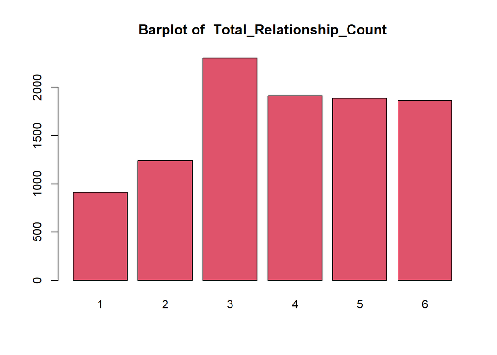

si osservare che la maggior parte delle persone hanno tra 3 e 5 prodotti coprendo il ~=60.31%, con la mggior parte avendo 3 prodotti a 2305 occoranze (~=22.76%) Si osserva che la differenza tra 4,5,6 prodotti è <1% e quindi si puo considerare di uguale possesso

# 5: Visualizazione Months_Inactive_12_mon

```r
visualization_discrete(na.omit(
  credit_w_numeric[,"Months_Inactive_12_mon",]), sum_info_c[5],"Months_Inactive_12_mon")
```

```
## [[1]]
## [[1]]$Months_Inactive_12_mon
## [[1]]$Months_Inactive_12_mon$Summary
##    Min. 1st Qu.  Median    Mean 3rd Qu.    Max.
##   0.000   2.000   2.000   2.341   3.000   6.000
##
## [[1]]$Months_Inactive_12_mon$Variance
## [1] 1.02
##
## [[1]]$Months_Inactive_12_mon$Standard_Deviation
## [1] 1.01
##
## [[1]]$Months_Inactive_12_mon$Moda
## [[1]]$Months_Inactive_12_mon$Moda$Mode
## [1] 3
##
## [[1]]$Months_Inactive_12_mon$Moda$Frequency
## [1] 3846
##
##
##
##
## [1] "freq: "
##
## data
##    0    1    2    3    4    5    6
##   29 2233 3282 3846  435  178  124
##
## [1] "percintile: "
##
## data
##          0          1          2          3          4          5          6
##  0.2863632 22.0499654 32.4084132 37.9776834  4.2954478  1.7576775  1.2244495
```

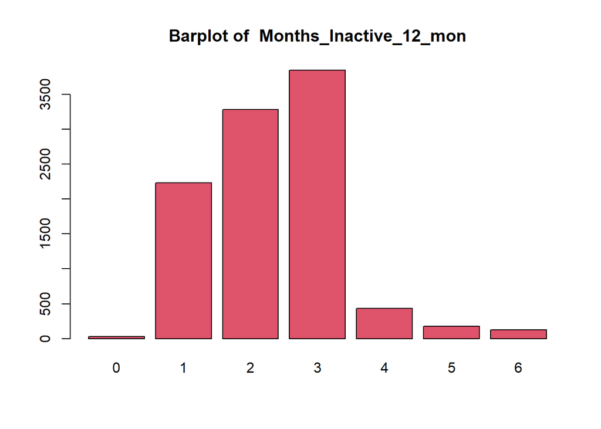

Possiamo osservare che la maggior parte delle persone rimangono innativi tra 1 e 3 mesi, con la maggior parte stando per 3 mesi con 3846 occoranze Si osserva che la maggior parte non vanno piu di 3 mesi prima di riattivare ma quasi sicuramente 1 mese e piu in quanto <1% rimangono attivi costantemente (0 mesi di innativita)

# 6: Visualizazione Contacts_Count_12_mon

```r
visualization_discrete(na.omit(
  credit_w_numeric[,"Contacts_Count_12_mon"]), sum_info_c[6],"Contacts_Count_12_mon")
```

```
## [[1]]
## [[1]]$Contacts_Count_12_mon
## [[1]]$Contacts_Count_12_mon$Summary
##    Min. 1st Qu.  Median    Mean 3rd Qu.    Max.
##   0.000   2.000   2.000   2.455   3.000   6.000
##
## [[1]]$Contacts_Count_12_mon$Variance
## [1] 1.22
##
## [[1]]$Contacts_Count_12_mon$Standard_Deviation
## [1] 1.11
##
## [[1]]$Contacts_Count_12_mon$Moda
## [[1]]$Contacts_Count_12_mon$Moda$Mode
## [1] 3
##
## [[1]]$Contacts_Count_12_mon$Moda$Frequency
## [1] 3380
##
##
##
##
## [1] "freq: "
##
## data
##    0    1    2    3    4    5    6
##  399 1499 3227 3380 1392  176   54
##
## [1] "percintile: "
##
## data
##         0         1         2         3         4         5         6
##  3.939962 14.802014 31.865311 33.376123 13.745433  1.737928  0.533228
```

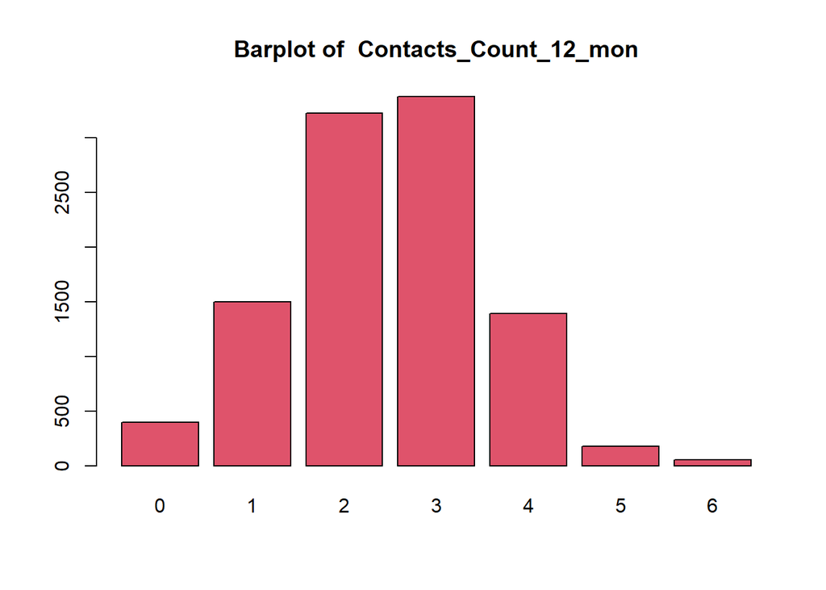

Possiamo osservare che la maggior parte delle persone hanno tra 2 e 3 contanti/12mesi, con la maggior parte avendo 3 contanti con 3380 occoranze

# 7: Visualizazione Credit_Limit

```r
visualization_continuos(na.omit(credit_w_numeric[,"Credit_Limit"]), sum_info_c[7],"Credit_Limit")
```

```
## [[1]]
## [[1]]$Credit_Limit
## [[1]]$Credit_Limit$Summary
##    Min. 1st Qu.  Median    Mean 3rd Qu.    Max.
##    1438    2555    4549    8632   11068   34516
##
## [[1]]$Credit_Limit$Variance
## [1] 82605861
##
## [[1]]$Credit_Limit$Standard_Deviation
## [1] 9088.78
##
## [[1]]$Credit_Limit$Moda
## [[1]]$Credit_Limit$Moda$Mode
## [1] 34516
##
## [[1]]$Credit_Limit$Moda$Frequency
## [1] 508
```

```
##
## Call:
##  density.default(x = data)
##
## Data: data (10127 obs.); Bandwidth 'bw' = 903.9
##
##        x               y
##  Min.   :-1273   Min.   :2.553e-07
##  1st Qu.: 8352   1st Qu.:5.913e-06
##  Median :17977   Median :1.145e-05
##  Mean   :17977   Mean   :2.594e-05
##  3rd Qu.:27602   3rd Qu.:2.660e-05
##  Max.   :37228   Max.   :1.574e-04
```

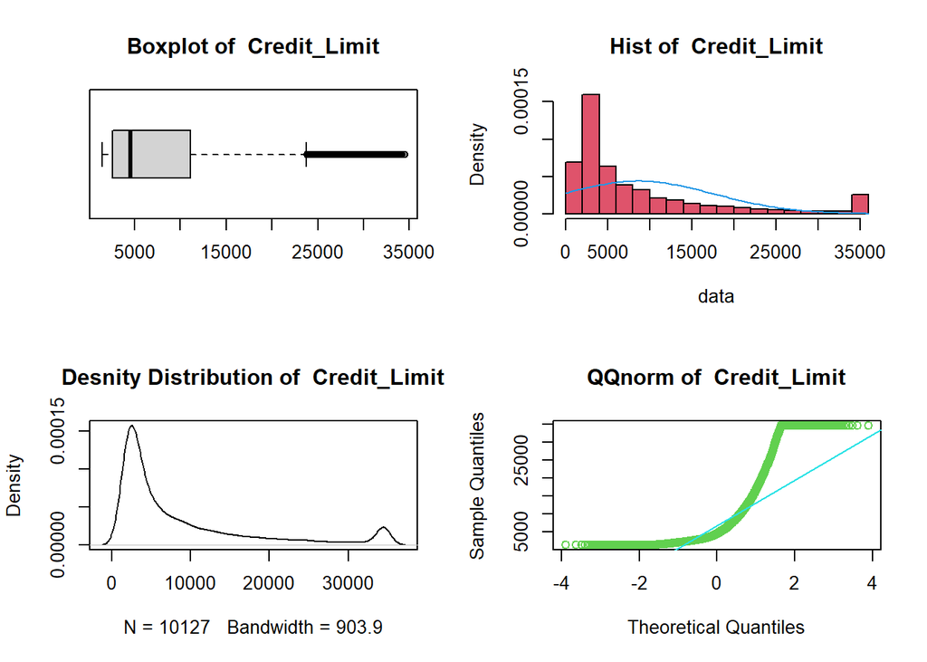

Possiamo osservare che la maggior parte delle persone hanno un limite di credito tra 2555 e 11068, ed esiste un anomalia al limite superiore dove non rispetta la descrescita delle occoranze del limite di credito con 34516 avendo 508 occoranze ed essendo il max pur non facendo parte del IQR

# 8: Visualizazione Total_Revolving_Bal

```r
visualization_continuos(na.omit(
  credit_w_numeric[,"Total_Revolving_Bal"]), sum_info_c[8],"Total_Revolving_Bal")
```

```
## [[1]]
## [[1]]$Total_Revolving_Bal
## [[1]]$Total_Revolving_Bal$Summary
##    Min. 1st Qu.  Median    Mean 3rd Qu.    Max.
##       0     359    1276    1163    1784    2517
##
## [[1]]$Total_Revolving_Bal$Variance
## [1] 664204.4
##
## [[1]]$Total_Revolving_Bal$Standard_Deviation
## [1] 814.99
##
## [[1]]$Total_Revolving_Bal$Moda
## [[1]]$Total_Revolving_Bal$Moda$Mode
## [1] 0
##
## [[1]]$Total_Revolving_Bal$Moda$Frequency
## [1] 2470
```

```
##
## Call:
##  density.default(x = data)
##
## Data: data (10127 obs.); Bandwidth 'bw' = 116
##
##        x                y
##  Min.   :-347.9   Min.   :2.141e-06
##  1st Qu.: 455.3   1st Qu.:1.690e-04
##  Median :1258.5   Median :3.021e-04
##  Mean   :1258.5   Mean   :3.108e-04
##  3rd Qu.:2061.7   3rd Qu.:4.447e-04
##  Max.   :2864.9   Max.   :8.415e-04
```

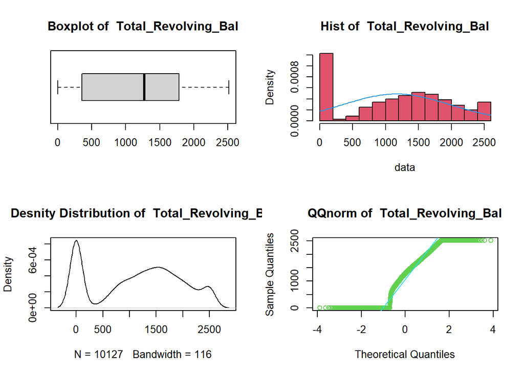

Possiamo notare che la maggior parte delle persone hanno Prestito a saldo rotativo compresa tra 359 e 1784, essendo rispettivamente il 1° e il 3° quantile e con maggior densita alineati alla retta qq della norma. Possiamo notare che la maggior parte delle persone hanno un Prestito a saldo rotativo a 0, 2470 in totale Per analizare quelli che hanno serve ignorare quelli senza

## Rimozione dello 0

```r
rm_0_data = rm_0(na.omit(
  credit_w_numeric[,"Total_Revolving_Bal"]))
visualization_continuos(rm_0_data, univariate_analysis(rm_0_data,"Total_Revolving_Bal"),"Total_Revolving_Bal")
```

```
## $Total_Revolving_Bal
## $Total_Revolving_Bal$Summary
##    Min. 1st Qu.  Median    Mean 3rd Qu.    Max.
##     132    1132    1524    1538    1935    2517
##
## $Total_Revolving_Bal$Variance
## [1] 301542.4
##
## $Total_Revolving_Bal$Standard_Deviation
## [1] 549.13
##
## $Total_Revolving_Bal$Moda
## $Total_Revolving_Bal$Moda$Mode
## [1] 2517
##
## $Total_Revolving_Bal$Moda$Frequency
## [1] 508
```

```
##
## Call:
##  density.default(x = data)
##
## Data: data (7657 obs.);  Bandwidth 'bw' = 82.62
##
##        x                y
##  Min.   :-115.9   Min.   :4.030e-08
##  1st Qu.: 604.3   1st Qu.:1.053e-04
##  Median :1324.5   Median :3.810e-04
##  Mean   :1324.5   Mean   :3.468e-04
##  3rd Qu.:2044.7   3rd Qu.:5.380e-04
##  Max.   :2764.9   Max.   :6.810e-04
```

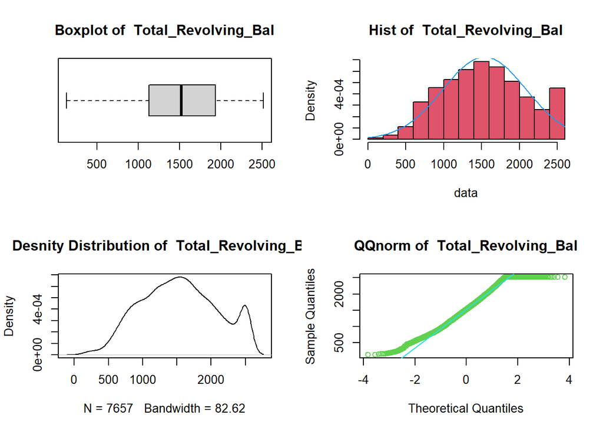

Possiamo notare che la maggior parte delle persone hanno Prestito a saldo rotativo compresa tra 1132 e 1935, essendo rispettivamente il 1° e il 3° quantile e con maggior densita alineati alla retta qq della norma. Possiamo notare che la maggior parte delle persone hanno un Prestito a saldo rotativo a 2517 per un totale di 508 persone esendo fuori dal IQR

# 9: Visualizazione Avg_Open_To_Buy

```r
visualization_continuos(na.omit(
  credit_w_numeric[,"Avg_Open_To_Buy"]), sum_info_c[9],"Avg_Open_To_Buy")
```

```
## [[1]]
## [[1]]$Avg_Open_To_Buy
## [[1]]$Avg_Open_To_Buy$Summary
##    Min. 1st Qu.  Median    Mean 3rd Qu.    Max.
##       3    1324    3474    7469    9859   34516
##
## [[1]]$Avg_Open_To_Buy$Variance
## [1] 82640560
##
## [[1]]$Avg_Open_To_Buy$Standard_Deviation
## [1] 9090.69
##
## [[1]]$Avg_Open_To_Buy$Moda
## [[1]]$Avg_Open_To_Buy$Moda$Mode
## [1] 1438.3
##
## [[1]]$Avg_Open_To_Buy$Moda$Frequency
## [1] 324
```

```
##
## Call:
##  density.default(x = data)
##
## Data: data (10127 obs.); Bandwidth 'bw' = 906.2
##
##        x               y
##  Min.   :-2716   Min.   :5.349e-08
##  1st Qu.: 7272   1st Qu.:5.472e-06
##  Median :17260   Median :1.138e-05
##  Mean   :17260   Mean   :2.501e-05
##  3rd Qu.:27247   3rd Qu.:2.493e-05
##  Max.   :37235   Max.   :1.607e-04
```

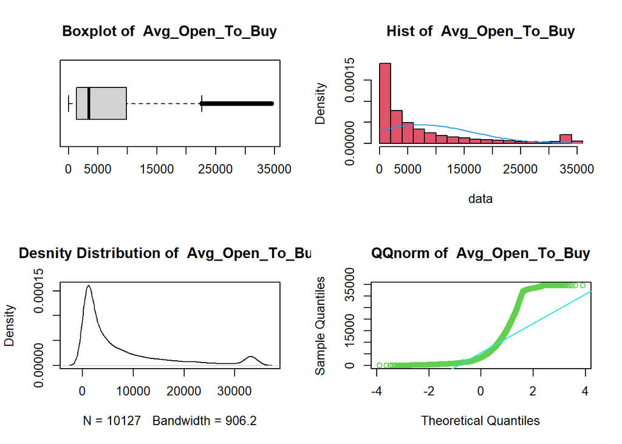

# 10: Visualizazione Total_Amt_Chng_Q4_Q1

```r
visualization_continuos(na.omit(
  credit_w_numeric[,"Total_Amt_Chng_Q4_Q1"]), sum_info_c[10],"Total_Amt_Chng_Q4_Q1")
```

```
## [[1]]
## [[1]]$Total_Amt_Chng_Q4_Q1
## [[1]]$Total_Amt_Chng_Q4_Q1$Summary
##    Min. 1st Qu.  Median    Mean 3rd Qu.    Max.
##  0.0000  0.6310  0.7360  0.7599  0.8590  3.3970
##
## [[1]]$Total_Amt_Chng_Q4_Q1$Variance
## [1] 0.05
##
## [[1]]$Total_Amt_Chng_Q4_Q1$Standard_Deviation
## [1] 0.22
##
## [[1]]$Total_Amt_Chng_Q4_Q1$Moda
## [[1]]$Total_Amt_Chng_Q4_Q1$Moda$Mode
## [1] 0.791
##
## [[1]]$Total_Amt_Chng_Q4_Q1$Moda$Frequency
## [1] 36
```

```
##
## Call:
##  density.default(x = data)
##
## Data: data (10127 obs.); Bandwidth 'bw' = 0.02421
##
##        x                  y
##  Min.   :-0.07263   Min.   :0.0000000
##  1st Qu.: 0.81294   1st Qu.:0.0009398
##  Median : 1.69850   Median :0.0068703
##  Mean   : 1.69850   Mean   :0.2820299
##  3rd Qu.: 2.58406   3rd Qu.:0.1170530
##  Max.   : 3.46963   Max.   :2.4673806
```

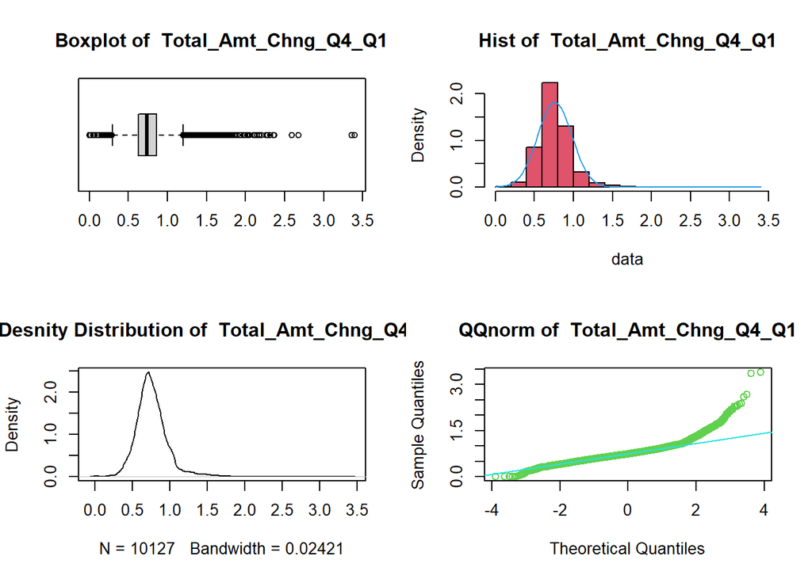

Possiamo notare che la maggior parte delle Variazione dell’importo della transazione (Q4 rispetto a Q1) è compresa tra 0.6310 e 0.8590, essendo rispettivamente il 1° e il 3° quantile e con maggior densita alineati alla retta qq della norma. Possiamo notare che la maggior parte delle Variazione dell’importo della transazione (Q4 rispetto a Q1) sono a 0.791 con 36 Variazione

## rimozione di outlier per Total_Amt_Chng_Q4_Q1

```r
rm_outlier_data = rm_oultiers(na.omit(credit_w_numeric[,"Total_Amt_Chng_Q4_Q1"]),.98)
visualization_continuos(rm_outlier_data, univariate_analysis(rm_outlier_data,"Total_Amt_Chng_Q4_Q1"),"Total_Amt_Chng_Q4_Q1")
```

```
## $Total_Amt_Chng_Q4_Q1
## $Total_Amt_Chng_Q4_Q1$Summary
##    Min. 1st Qu.  Median    Mean 3rd Qu.    Max.
##  0.2510  0.6290  0.7320  0.7411  0.8480  1.2690
##
## $Total_Amt_Chng_Q4_Q1$Variance
## [1] 0.03
##
## $Total_Amt_Chng_Q4_Q1$Standard_Deviation
## [1] 0.17
##
## $Total_Amt_Chng_Q4_Q1$Moda
## $Total_Amt_Chng_Q4_Q1$Moda$Mode
## [1] 0.791
##
## $Total_Amt_Chng_Q4_Q1$Moda$Frequency
## [1] 36
```

```
##
## Call:
##  density.default(x = data)
##
## Data: data (9822 obs.);  Bandwidth 'bw' = 0.0234
##
##        x                y
##  Min.   :0.1808   Min.   :0.0000433
##  1st Qu.:0.4704   1st Qu.:0.1271346
##  Median :0.7600   Median :0.5689233
##  Mean   :0.7600   Mean   :0.8624335
##  3rd Qu.:1.0496   3rd Qu.:1.5598759
##  Max.   :1.3392   Max.   :2.5517658
```

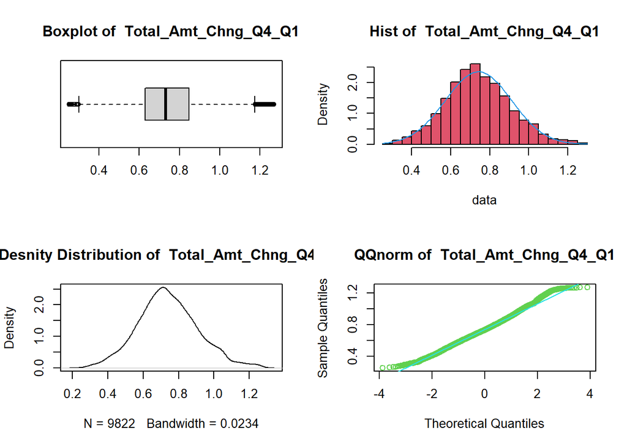

Possiamo dedurre che la distribuzione è semi-normato e che la maggior parte delle Variazione dell’importo della transazione (Q4 rispetto a Q1) sono compresa tra 0.6290 e 0.8480, essendo rispettivamente il 1° e il 3° quantile e con maggior densita alineati alla retta qq della norma. Possiamo notare che la maggior parte delle Variazione delle Variazione dell’importo della transazione (Q4 rispetto a Q1) sono a 0.791 con 36 Variazione

# 11: Visualizazione Total_Trans_Amt

```r
visualization_continuos(na.omit(
  credit_w_numeric[,"Total_Trans_Amt"]), sum_info_c[11],"Total_Trans_Amt")
```

```
## [[1]]
## [[1]]$Total_Trans_Amt
## [[1]]$Total_Trans_Amt$Summary
##    Min. 1st Qu.  Median    Mean 3rd Qu.    Max.
##     510    2156    3899    4404    4741   18484
##
## [[1]]$Total_Trans_Amt$Variance
## [1] 11540487
##
## [[1]]$Total_Trans_Amt$Standard_Deviation
## [1] 3397.13
##
## [[1]]$Total_Trans_Amt$Moda
## [[1]]$Total_Trans_Amt$Moda$Mode
## [1] 4253 4509
##
## [[1]]$Total_Trans_Amt$Moda$Frequency
## [1] 11
```

```
##
## Call:
##  density.default(x = data)
##
## Data: data (10127 obs.); Bandwidth 'bw' = 274.5
##
##        x                 y
##  Min.   : -313.6   Min.   :1.640e-09
##  1st Qu.: 4591.7   1st Qu.:2.146e-06
##  Median : 9497.0   Median :1.323e-05
##  Mean   : 9497.0   Mean   :5.092e-05
##  3rd Qu.:14402.3   3rd Qu.:3.987e-05
##  Max.   :19307.6   Max.   :2.976e-04
```

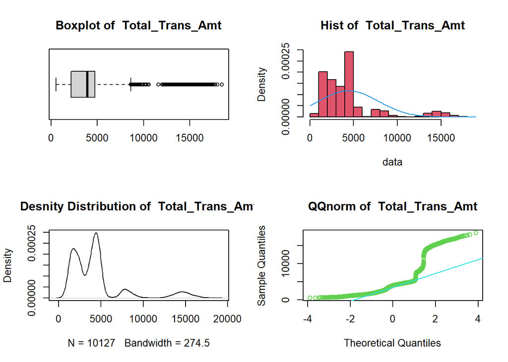

Possiamo notare che la maggior parte delle Importe totali delle transazioni sono compresa tra 2156 e 4741, essendo rispettivamente il 1° e il 3° quantile e con maggior densita alineati alla retta qq della norma. Possiamo notare che la maggior parte delle Importe totali delle transazioni sono a 4253 e 4509 con 11 transazioni

# 12: Visualizazione Total_Trans_Ct

```r
visualization_continuos(na.omit(
  credit_w_numeric[,"Total_Trans_Ct"]), sum_info_c[12],"Total_Trans_Ct")
```

```
## [[1]]
## [[1]]$Total_Trans_Ct
## [[1]]$Total_Trans_Ct$Summary
##    Min. 1st Qu.  Median    Mean 3rd Qu.    Max.
##   10.00   45.00   67.00   64.86   81.00  139.00
##
## [[1]]$Total_Trans_Ct$Variance
## [1] 550.96
##
## [[1]]$Total_Trans_Ct$Standard_Deviation
## [1] 23.47
##
## [[1]]$Total_Trans_Ct$Moda
## [[1]]$Total_Trans_Ct$Moda$Mode
## [1] 81
##
## [[1]]$Total_Trans_Ct$Moda$Frequency
## [1] 208
```

```
##
## Call:
##  density.default(x = data)
##
## Data: data (10127 obs.); Bandwidth 'bw' = 3.34
##
##        x                   y
##  Min.   : -0.01909   Min.   :1.860e-07
##  1st Qu.: 37.24046   1st Qu.:1.141e-03
##  Median : 74.50000   Median :4.058e-03
##  Mean   : 74.50000   Mean   :6.703e-03
##  3rd Qu.:111.75954   3rd Qu.:1.182e-02
##  Max.   :149.01909   Max.   :1.885e-02
```

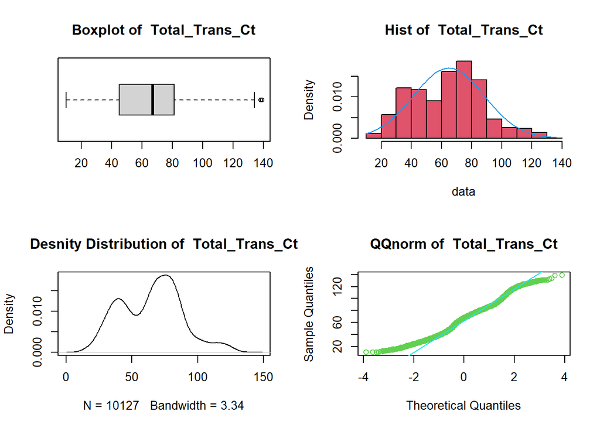

Possiamo dedurre che la distribuzione è semi-normato positivamente assimetrica e che la maggior parte delle Conteggio totale delle transazioni sono compresa tra 45.00 e 81.00, essendo rispettivamente il 1° e il 3° quantile e con maggior densita alineati alla retta qq della norma. Possiamo notare che la maggior parte delle Variazione delle Conteggio totale delle transazioni sono a 81 con 208 occoranze

# 13: Visualizazione Total_Ct_Chng_Q4_Q1

```r
visualization_continuos(na.omit(
  credit_w_numeric[,"Total_Ct_Chng_Q4_Q1"]), sum_info_c[13],"Total_Ct_Chng_Q4_Q1")
```

```
## [[1]]
## [[1]]$Total_Ct_Chng_Q4_Q1
## [[1]]$Total_Ct_Chng_Q4_Q1$Summary
##    Min. 1st Qu.  Median    Mean 3rd Qu.    Max.
##  0.0000  0.5820  0.7020  0.7122  0.8180  3.7140
##
## [[1]]$Total_Ct_Chng_Q4_Q1$Variance
## [1] 0.06
##
## [[1]]$Total_Ct_Chng_Q4_Q1$Standard_Deviation
## [1] 0.24
##
## [[1]]$Total_Ct_Chng_Q4_Q1$Moda
## [[1]]$Total_Ct_Chng_Q4_Q1$Moda$Mode
## [1] 0.667
##
## [[1]]$Total_Ct_Chng_Q4_Q1$Moda$Frequency
## [1] 171
```

```
##
## Call:
##  density.default(x = data)
##
## Data: data (10127 obs.); Bandwidth 'bw' = 0.02506
##
##        x                  y
##  Min.   :-0.07518   Min.   :0.000000
##  1st Qu.: 0.89091   1st Qu.:0.001310
##  Median : 1.85700   Median :0.007164
##  Mean   : 1.85700   Mean   :0.258526
##  3rd Qu.: 2.82309   3rd Qu.:0.120710
##  Max.   : 3.78918   Max.   :2.289734
```

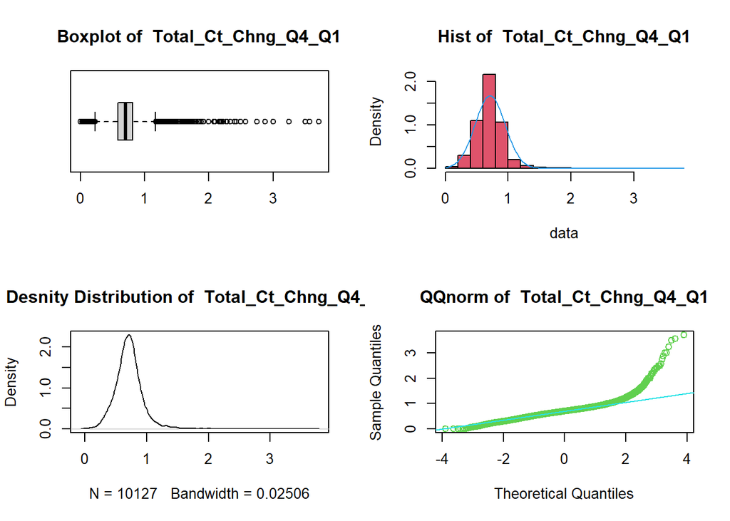

```r
rm_outlier_data = rm_oultiers(na.omit(credit_w_numeric[,"Total_Ct_Chng_Q4_Q1"]),.98)
visualization_continuos(rm_outlier_data, univariate_analysis(rm_outlier_data,"Total_Ct_Chng_Q4_Q1"),"Total_Ct_Chng_Q4_Q1")
```

```
## $Total_Ct_Chng_Q4_Q1
## $Total_Ct_Chng_Q4_Q1$Summary
##    Min. 1st Qu.  Median    Mean 3rd Qu.    Max.
##  0.1610  0.5810  0.6980  0.6959  0.8100  1.2630
##
## $Total_Ct_Chng_Q4_Q1$Variance
## [1] 0.03
##
## $Total_Ct_Chng_Q4_Q1$Standard_Deviation
## [1] 0.19
##
## $Total_Ct_Chng_Q4_Q1$Moda
## $Total_Ct_Chng_Q4_Q1$Moda$Mode
## [1] 0.667
##
## $Total_Ct_Chng_Q4_Q1$Moda$Frequency
## [1] 171
```

```
##
## Call:
##  density.default(x = data)
##
## Data: data (9878 obs.);  Bandwidth 'bw' = 0.02444
##
##        x                 y
##  Min.   :0.08769   Min.   :0.0001072
##  1st Qu.:0.39985   1st Qu.:0.1444697
##  Median :0.71200   Median :0.5058148
##  Mean   :0.71200   Mean   :0.8001016
##  3rd Qu.:1.02415   3rd Qu.:1.3695197
##  Max.   :1.33631   Max.   :2.3510407
```

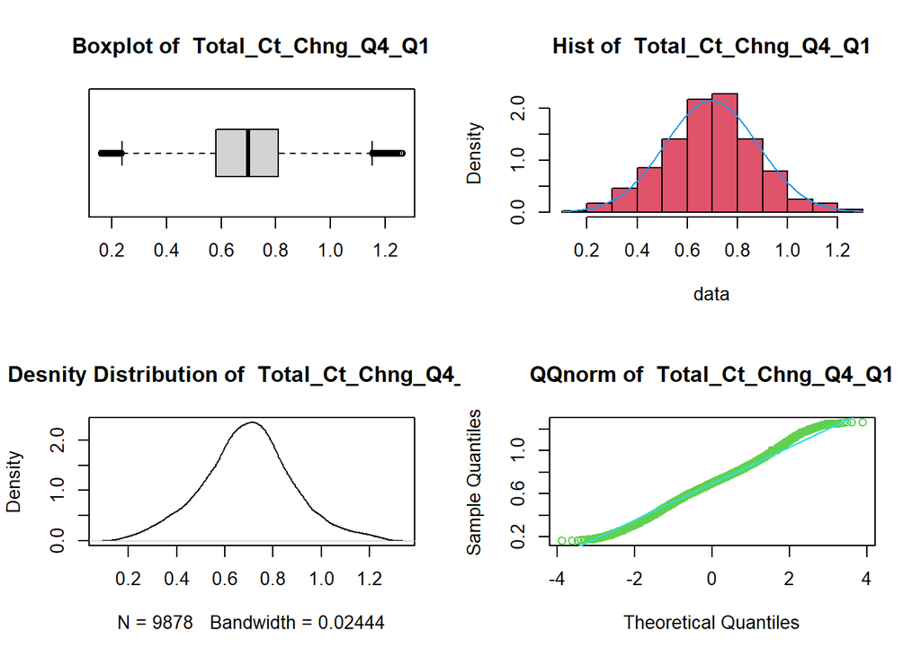

Possiamo dedurre che la distribuzione è semi-normato e che la maggior parte delle Variazione delle Variazione nel conteggio delle transazioni (Q4 rispetto a Q1) è compresa tra 0.5810 e 0.8100, essendo rispettivamente il 1° e il 3° quantile e con maggior densita alineati alla retta qq della norma. Possiamo notare che la maggior parte delle Variazione elle Variazione delle Variazione nel conteggio delle transazioni (Q4 rispetto a Q1) sono a 0.667 con 171 Variazione

# 14: Visualizazione Avg_Utilization_Ratio

```r
visualization_continuos(na.omit(
  credit_w_numeric[,"Avg_Utilization_Ratio"]), sum_info_c[14],"Avg_Utilization_Ratio")
```

```
## [[1]]
## [[1]]$Avg_Utilization_Ratio
## [[1]]$Avg_Utilization_Ratio$Summary
##    Min. 1st Qu.  Median    Mean 3rd Qu.    Max.
##  0.0000  0.0230  0.1760  0.2749  0.5030  0.9990
##
## [[1]]$Avg_Utilization_Ratio$Variance
## [1] 0.08
##
## [[1]]$Avg_Utilization_Ratio$Standard_Deviation
## [1] 0.28
##
## [[1]]$Avg_Utilization_Ratio$Moda
## [[1]]$Avg_Utilization_Ratio$Moda$Mode
## [1] 0
##
## [[1]]$Avg_Utilization_Ratio$Moda$Frequency
## [1] 2470
```

```
##
## Call:
##  density.default(x = data)
##
## Data: data (10127 obs.); Bandwidth 'bw' = 0.03923
##
##        x                 y
##  Min.   :-0.1177   Min.   :0.0000855
##  1st Qu.: 0.1909   1st Qu.:0.3492169
##  Median : 0.4995   Median :0.6801743
##  Mean   : 0.4995   Mean   :0.8090999
##  3rd Qu.: 0.8081   3rd Qu.:0.9021584
##  Max.   : 1.1167   Max.   :3.1604425
```

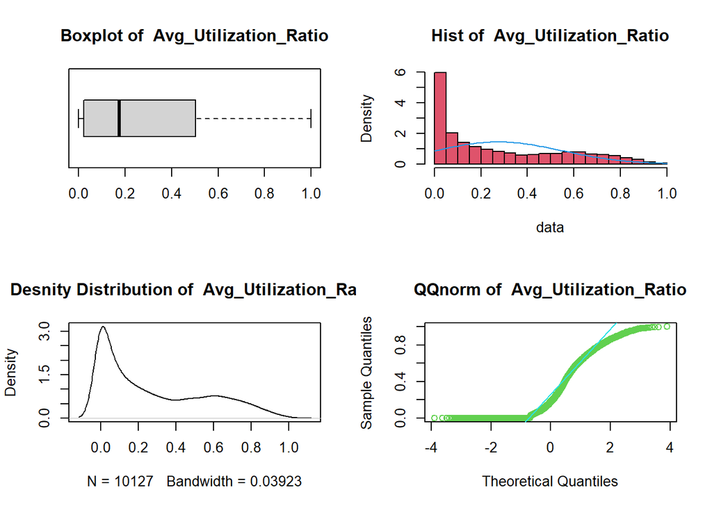

```r
detach(credit_w_numeric)
```